# A Random Walk Through the Web: Network Analysis of the Google Web Graph

## Google Dataset

- Released by Google in \(2002\) as part of the Google Programming Contest
- Made publicly available through the Stanford Network Analysis Project (SNAP)
- 2002: aftermath of the dotcom bubble effecting the internet space

## Dataset Description

Basic Network Elements of the web-Google Network

| Property | Value |
| --- | --- |
| Nodes | 875713 |
| Edges | 5105039 |
| Directionality | Yes |
| Weighted | No |
| Self-loops | No |
| Density | 6.7e-06 |
| Mean Degree | 11.66 |
| Max Degree | 6353 |

## Objectives

- Generate representative subgraphs of the Google Web graph using random walk sampling to deal with sparsity limitations of induced subgraphs
- Look into sampling bias by comparing degree distributions between the sampled subgraph and full network using the Kolmpgorov-Smirnov test
- Visualize the network structure of our subgraphs with the Fruchterman-Reingold, Kamada-Kawai, and Multidimensional Scaling (MDS) layout to reveal structural and connectivity patterns
- Compute and interpret network-level metrics (i.e. density, reciprocity, dyad census, transitivity, diameter, and mean distance) to capture the overall structure of the web graph
- Compute and interpret node-level metrics (i.e. in-degree, out-degree, betweenness centrality, closness centrality, and local transitivity) to identify influential web pages within the network
- Detect and compare communities using Fast-Greedy, Louvain, Walktrap algorithms and evaluate their results using molecularity scores and community sizes
- Examine the adjacency matrix of each subgraphs in their original and reordered form to confirm the presence of community strucutre and identify structural patterns.

## `induced_subgraph()` Implemenation

```
## IGRAPH d2a5517 DN-- 200 1 --
## + attr: name (v/c)
## + edge from d2a5517 (vertex names):
## [1] 860469->343525
```

```
## IGRAPH 33b26c8 DN-- 200 0 --
## + attr: name (v/c)
## + edges from 33b26c8 (vertex names):
```

```
## IGRAPH 3e08cab DN-- 200 0 --
## + attr: name (v/c)
## + edges from 3e08cab (vertex names):
```

```
## IGRAPH a22631e DN-- 200 1 --
## + attr: name (v/c)
## + edge from a22631e (vertex names):
## [1] 203345->306718
```

## Random Walk Sampling Code

```r
set.seed(123)

subgraphs <- list()

for(i in 1:4){
  start_node <- sample(V(graph), 1)
  walk <- random_walk(graph,
                      start = start_node,
                      steps = 500,
                      mode = "all")
  nodes_sampled <- unique(walk)
  nodes_sampled <- nodes_sampled[1:200]
  subgraphs[[i]] <- induced_subgraph(graph, nodes_sampled)
}
```

## Checking Random Walk Sampling

Sampling Bias Assessment of Random Walk Subgraphs

| Subgraph | Nodes | Edges | Mean Degree | Median Degree | KS P-Value |
| --- | --- | --- | --- | --- | --- |
| Subgraph 1 | 200 | 957 | 9.57 | 7 | 0.0000337 |
| Subgraph 2 | 200 | 970 | 9.70 | 5 | 0.0062651 |
| Subgraph 3 | 200 | 842 | 8.42 | 6 | 0.0000047 |
| Subgraph 4 | 200 | 1608 | 16.08 | 12 | 0.0000000 |

## Subgraph 4 Visuals

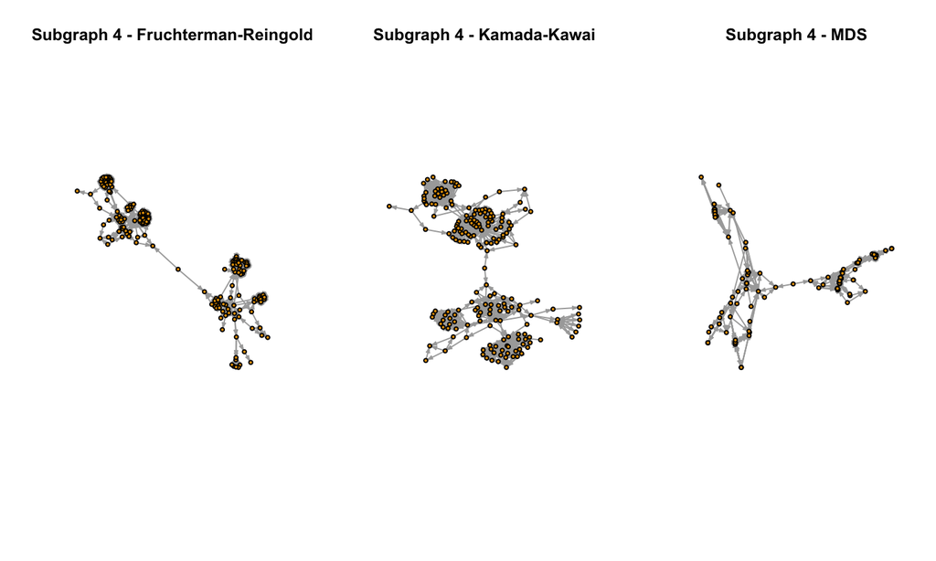

## Metrics - Structure & Connectivity

| Metric | Value |
| --- | --- |
| Density | 0.0404 |
| Centralization | 0.1460 |
| Avg Path Length | 5.2920 |
| Reciprocity | 0.4280 |
| Transitivity | 0.6700 |

- **Low density** confirms sparse web graph structure
- **Low Centralization** shows lack of dominant hub in subgraph
- **Reciprocity** reflects observations of close-knit communities
- **Transitivity** indicates high degree of local clustering

## Community Detection

- Fast Greedy, Louvain, and Walktrap

| Subgraph | Algorithm | N_communities | Modularity_Q | Max_Comm_Size |
| --- | --- | --- | --- | --- |
| 4 | Fast Greedy | 7 | 0.7436 | 40 |
| 4 | Louvain | 8 | 0.7396 | 38 |
| 4 | Walktrap | 12 | 0.7357 | 38 |

## Community Detection

- Walktrap detects more communities than other algorithms
  - Fast greedy and Louvain typically struggle to see smaller communities
  - Implies a hierarchical/subcommunity structure
- Stable results with modularity of around 0.7 or higher
- Largest community is less than a quarter of entire network size

## Subgraph 4 Community Detection Visualization

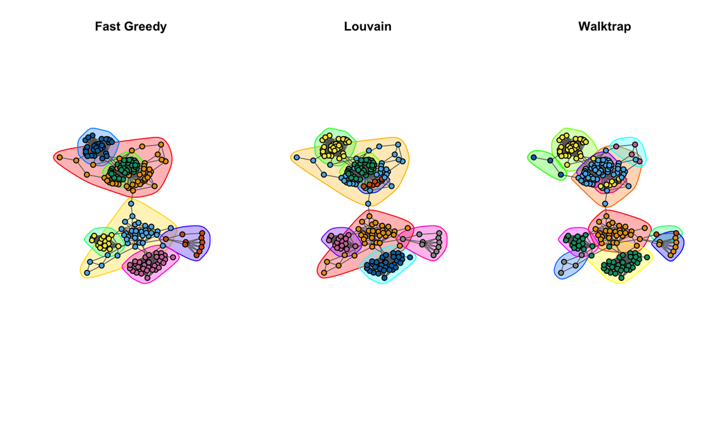

## Adjacency Matrix: Reordered by Community

- Nodes reordered by Louvain community membership
- Diagonal blocks emerge — pages in the same community densely hyperlink each other
- Subgraph 4 (1,608 edges) shows the clearest block structure
- Off-diagonal sparsity confirms pages from different communities rarely link directly

## Adjacency Matrix Reordered

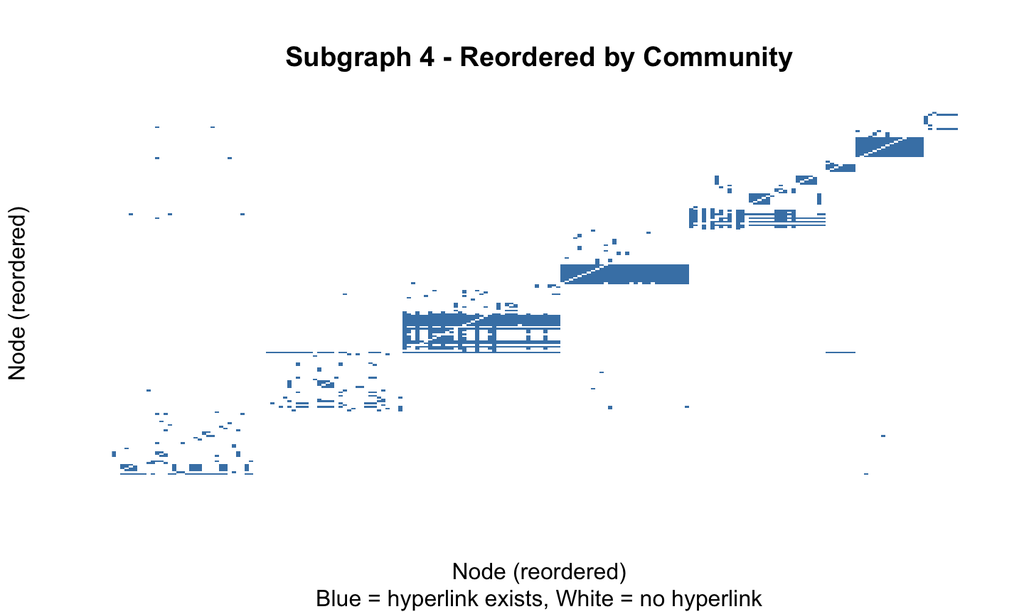

## Reordering Nodes by Connected Component

- All 200 nodes in each subgraph belong to a single connected component
- Reordering by component yields identical results to community reordering
- Two patterns visible in reordered matrices:
  - **L-shape**: central hub page linking to many communities (e.g. Wikipedia-like pages)
  - **Solid block**: tightly interconnected pages, likely subpages of the same site

## Conclusion

- Random Walk sampling allowed us to analyze meaningful locally connected regions for our sparse Google web graph
- Our sampled network consistently showed strong community structure, where webpages cluster into tightly connected groups
- High reciprocity and transitivity indicatet that webpages frequently link within their own communities
- Community detection algorithms produces high modularity (\(\approx 0.7+\)), confirming well-defined communities
- Walktrap detected more communities than Louvian and Fast-Greedy - hierarchical subcommunities within larger clusters
- Reordered adjacency matrices revealed clear block-diagonal patterns - hyperlinks are concentrated within topical clusters rather than randomly distributed
- Occasional hub-like pages connect multiple communities - bridges between different topics

## Future Direction

- Analyze larger sampled subgraphs to capture more global network structure
- Compare different network sampling methods to reduce sampling bias
- Explore temporal web datasets to study how web structure evolved over time